# Visualizations

Ryan Miller

## Introduction

- This presentation will cover two topics:
1. A few principles for making effective choices in the visualizations you construct
2. A variety of visualizations that you likely didn’t encounter in your intro stats class, but you can create in R! (with the midterm project in mind)

## Principles

- Visualizations encode data using visual “cues”, or mappings of the data to variations in size, shape, color, etc.
- Not all cues are equally effective in accurately conveying the quantitative information contained in data
- In the 1980s, two statisticians, William Cleveland and Robert McGill, [ran a series of experiments](http://courses.ischool.berkeley.edu/i247/f05/readings/Cleveland_GraphicalPerception_Science85.pdf) measuring how accurately human subjects preceived quantitative information from different visual cues.

## Visual Cues

- Cleveland and McGill’s experiments found the following hierarchy of visual cues:
  - Subjects most accurately preceived quantitative characteristics from judgements of position and length
  - Judgements of angle and slope were almost as accurate
  - Judgements based upon area and color intensity were less accurate
  - Judgements based upon volume were even less accurate

## Visual Cue Hierarchy - Example #1

Does the top representation (length) or bottom representation (area) better encode the underlying numeric differences in these five categories?

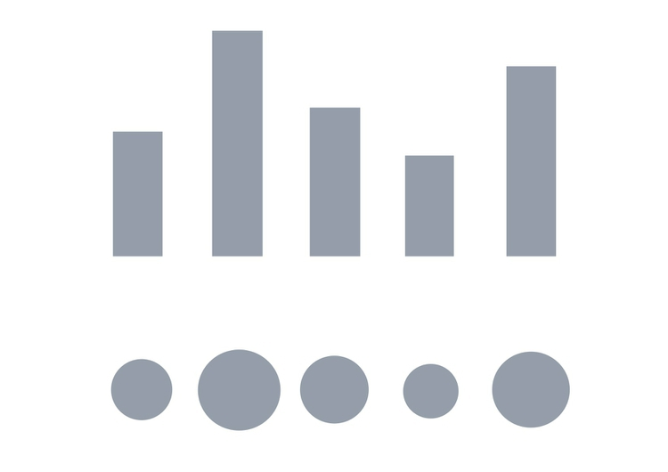

###### Source: Peter Aldhous https://paldhous.github.io/ucb/2016/dataviz.html

## Visual Cue Hierarchy - Example #2

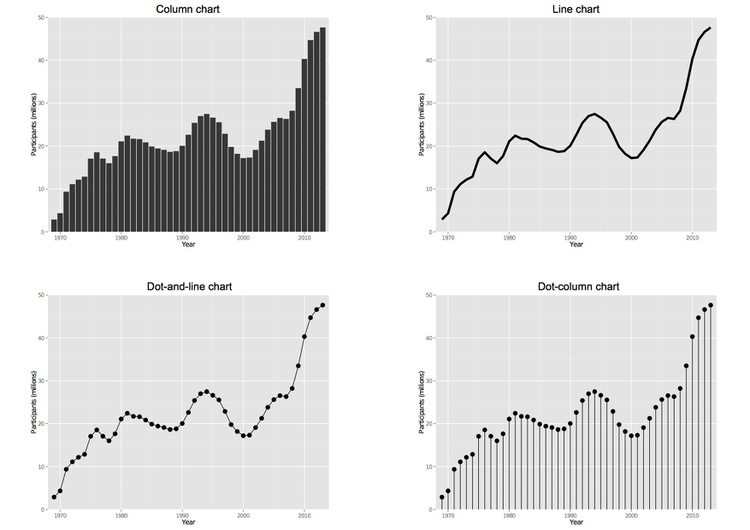

Notice how each chart communicates the same information, but draws your attention to different aspects.

- The column chart empthasizes each year’s value as a discrete point in time.
- The line chart empthasizes trajectory
- The dot-and-line chart and dot-column chart are compromises between these two approaches

###### Source: Peter Aldhous https://paldhous.github.io/ucb/2016/dataviz.html

## Takeaways

- To maximize how well your viewers preceive numeric values, use length-based visuals
  - Barcharts for category percentages, stacked barcharts for conditional relationships, etc.
- Piecharts aren’t useless, as people are decent at perceiving information through angles, but they also don’t scale as well as bar charts do
- Avoid forcing your viewers to make *important* judgements using area, color scales, or volume
  - Instead use these aesthetics for secondary comparisons, or for variables where quantitative judgements are less important
  - For example, if you use the area of the points on a scatterplot to depict a third variable, you should recognize that differences in this variable will be less acurately preceived than the variables shown on the x and y axes

## Radar Charts

- **Radar charts** (sometimes shown as spider charts) are a way of depicting scores for numeric variables for a small number of groups

```
##   group      var1      var2      var3      var4     var5
## 1     A 0.0000000 0.1894722 0.9777146 1.0000000 1.000000
## 2     B 1.0000000 1.0000000 0.0000000 0.1419618 0.802495
## 3     C 0.3637406 0.0000000 1.0000000 0.0000000 0.000000
```

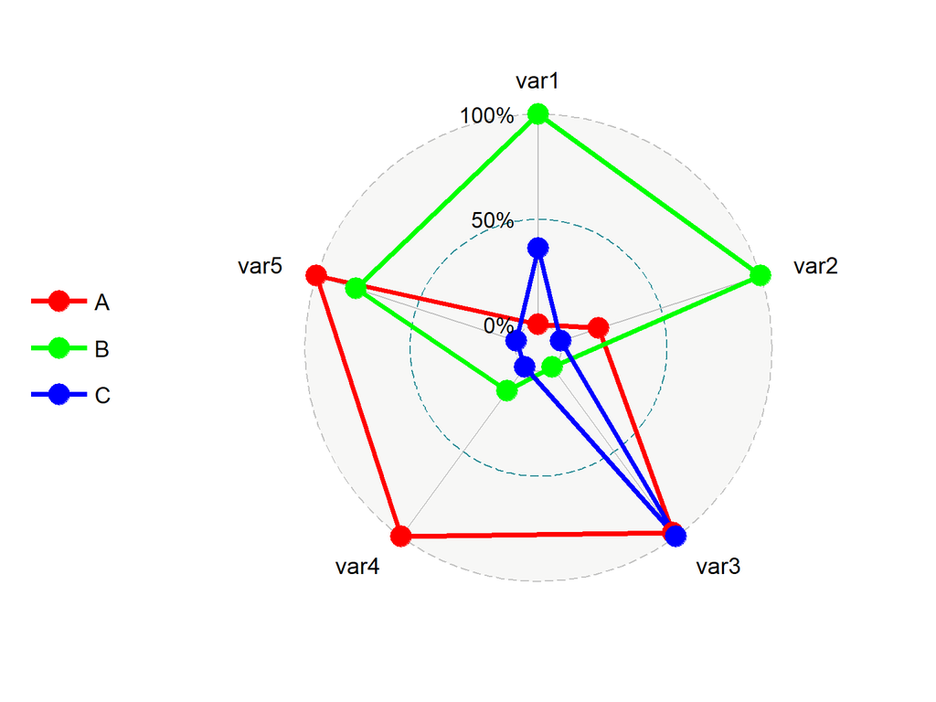

## Radar Charts - Example Code

```r
# devtools::install_github("ricardo-bion/ggradar") # This package must be installed from github using the "devtools" package
library(ggradar)
library(scales)
data <- data.frame(group = c("A", "B", "C"),
                   var1 = rescale(rnorm(3)),
                   var2 = rescale(rnorm(3)),
                   var3 = rescale(rnorm(3)),
                   var4 = rescale(rnorm(3)),
                   var5 = rescale(rnorm(3)))

## Note: the rescale function in the "scales" package is used to map values onto a [0,1] scale

ggradar(plot.data = data,
        group.colours = c("red", "green", "blue"))
```

## Radar Charts - Application

- Comparing the performance of two players on the Memphis Grizzlies (2013-14)

[figure not shown]

###### Source: https://www.researchgate.net/figure/a-Team-radar-chart-and-box-score-b-Player-radar-charts_fig2_310661881

## Treemaps

- **Treemaps** depict the composition of data with a nested structure (ie: each data-point has a main category and one or more subcategories)

| group | subgroup | value |
| --- | --- | --- |
| group-1 | subgroup-1 | 13 |
| group-1 | subgroup-2 | 5 |
| group-1 | subgroup-3 | 22 |
| group-1 | subgroup-4 | 12 |
| group-2 | subgroup-1 | 11 |
| group-2 | subgroup-2 | 7 |
| group-3 | subgroup-1 | 3 |
| group-3 | subgroup-2 | 1 |
| group-3 | subgroup-3 | 23 |

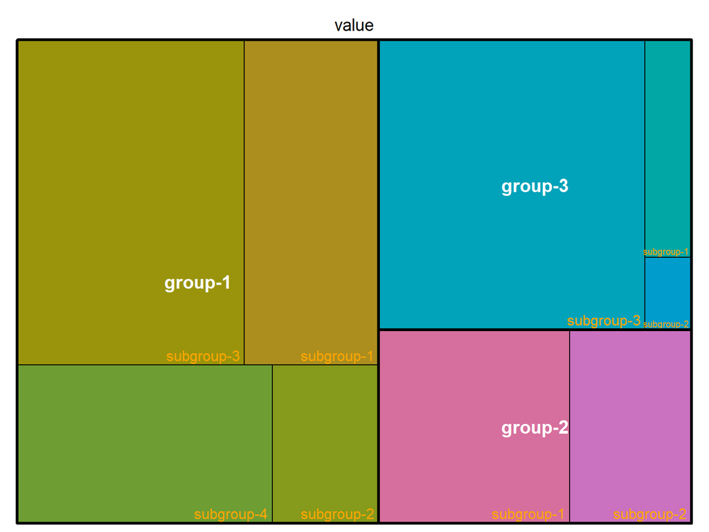

## Treemaps - Example Code

```r
library(treemap)
data <- data.frame(group = c(rep("group-1",4),rep("group-2",2),rep("group-3",3)),
                   subgroup = paste("subgroup" , c(1,2,3,4,1,2,1,2,3), sep="-"),
                   value = c(13,5,22,12,11,7,3,1,23))

treemap(data,
        index=c("group","subgroup"),
        vSize="value", type="index",
        fontsize.labels=c(15,12),           # size of labels (ie: size for group, size for subgroup, sub-subgroups...)
    fontcolor.labels=c("white","orange"),   # Color of labels
    fontface.labels=c(2,1),                   # Font of labels: 1 = normal, 2 = bold
    bg.labels=c("transparent"),               # Background color of labels
    align.labels=list(c("center", "center"),
                      c("right", "bottom")),    # Group label = center-center, subgroup labels = right-bottom
    overlap.labels=0.5,
    inflate.labels=F                        # If true, labels are bigger when rectangle is bigger.
)
```

## Treemaps - Application

- Displaying the exports of France

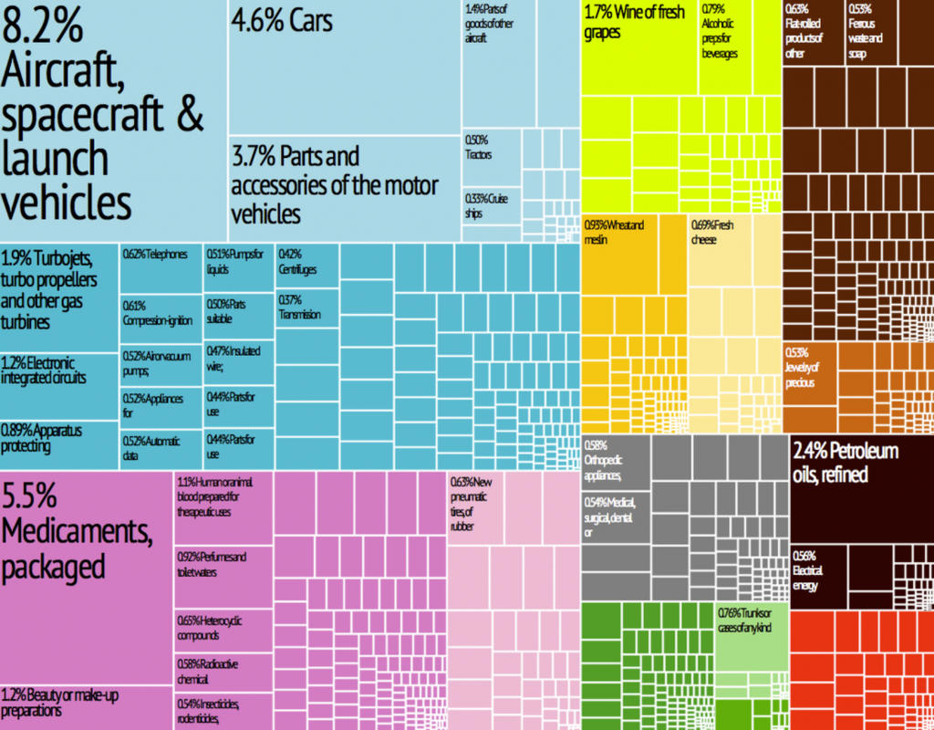

###### Source: https://iscpif.fr/2018/01/postdoctoral-researcher-position-mapping-economics-in-france-isc-pif/

## Stacked Area Charts

- **Stacked Area Charts** represent changes in counts or proportions over time

| time | group | value |
| --- | --- | --- |
| 1 | A | 25.42546 |
| 1 | B | 30.34203 |
| 1 | C | 70.11054 |
| 1 | D | 64.36381 |
| 1 | E | 93.72924 |
| 1 | F | 76.74978 |
| 1 | G | 24.16071 |
| 2 | A | 87.26334 |
| 2 | B | 54.00489 |
| 2 | C | 74.97030 |
| 2 | D | 77.39340 |
| 2 | E | 37.74548 |
| 2 | F | 11.25851 |
| 2 | G | 66.29368 |
| 3 | A | 39.36816 |
| 3 | B | 91.39390 |
| 3 | C | 17.90009 |
| 3 | D | 79.10068 |
| 3 | E | 96.47492 |
| 3 | F | 79.74737 |
| 3 | G | 16.36403 |
| 4 | A | 54.15328 |
| 4 | B | 96.27023 |
| 4 | C | 75.18214 |
| 4 | D | 60.44227 |
| 4 | E | 73.71466 |
| 4 | F | 41.62576 |
| 4 | G | 43.18518 |
| 5 | A | 30.75828 |
| 5 | B | 38.46621 |
| 5 | C | 61.88028 |
| 5 | D | 85.97456 |
| 5 | E | 38.05831 |
| 5 | F | 21.54447 |
| 5 | G | 91.36906 |
| 6 | A | 84.82081 |
| 6 | B | 63.67155 |
| 6 | C | 83.36836 |
| 6 | D | 35.71742 |
| 6 | E | 35.95104 |
| 6 | F | 32.95370 |
| 6 | G | 18.79741 |
| 7 | A | 43.18970 |
| 7 | B | 40.49496 |
| 7 | C | 29.05453 |
| 7 | D | 84.30594 |
| 7 | E | 33.81314 |
| 7 | F | 54.75820 |
| 7 | G | 22.12186 |

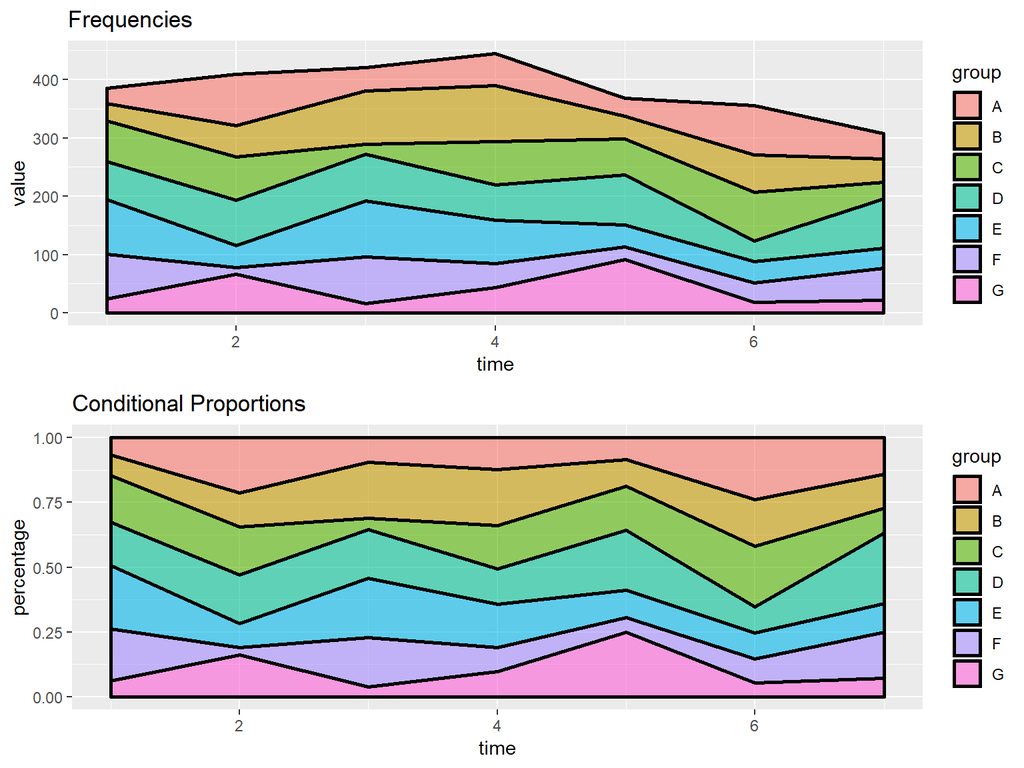

## Stacked Area Chart - Example Code

```r
data <- data.frame(time = as.numeric(rep(seq(1,7),each=7)),
                   group = rep(LETTERS[1:7],times=7),
                   value = runif(49, 10, 100))

# Compute percentages
data_per <- data  %>%
  group_by(time, group) %>%
  summarise(n = sum(value)) %>%
  mutate(percentage = n / sum(n))

# Plot #1 - Counts
p1 <- ggplot(data, aes(x=time, y=value, fill=group)) +
    geom_area(alpha=0.6 , size=1, color = "black") + labs(title = "Frequencies")

# Plot #2 - Percentages
p2 <- ggplot(data_per, aes(x=time, y=percentage, fill=group)) +
    geom_area(alpha=0.6 , size=1, color="black") + labs(title = "Conditional Proportions")

grid.arrange(p1, p2)
```

## Stacked Area Charts - Application

- Carbon emissions over time

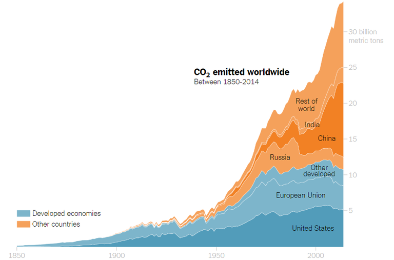

###### Source: https://www.nytimes.com/2019/02/28/learning/teach-about-climate-change-with-these-24-new-york-times-graphs.html

## Additional resources

I recommend you browse these repositories when considering what graphics to use in your midterm project:

- Graph types and example code: https://www.r-graph-gallery.com
- 50 ggplot visualizations with code: http://r-statistics.co/Top50-Ggplot2-Visualizations-MasterList-R-Code.html